# Peer-graded Assignment: Course Project 1

Abu Raihan Khalizan

June 17, 2019

## Loading and preprocessing the data

Show any code that is needed to

1. Load the data (i.e. read.csv())

```r
library(dplyr)
```

```r
library(knitr)
library(ggplot2)
setwd("D:/Users/firaihan/Desktop/DNFBP/2. Projects/DNFBP Project Data Science")
df <- read.csv("activity.csv", header=T, sep=",")
```

2. Process/transform the data (if necessary) into a format suitable for your analysis

```r
df$date <- as.Date(df$date)
df <- as_tibble(df)
```

## What is mean total number of steps taken per day?

For this part of the assignment, you can ignore the missing values in the dataset.

1. Calculate the total number of steps taken per day

```r
groupByDay <- group_by(df, date)
stepsByDay <- summarise(groupByDay, total = sum(steps))
stepsByDay
```

```
## # A tibble: 61 x 2
##    date       total
##    <date>     <int>
##  1 2012-10-01    NA
##  2 2012-10-02   126
##  3 2012-10-03 11352
##  4 2012-10-04 12116
##  5 2012-10-05 13294
##  6 2012-10-06 15420
##  7 2012-10-07 11015
##  8 2012-10-08    NA
##  9 2012-10-09 12811
## 10 2012-10-10  9900
## # ... with 51 more rows
```

2. If you do not understand the difference between a histogram and a barplot, research the difference between them. Make a histogram of the total number of steps taken each day

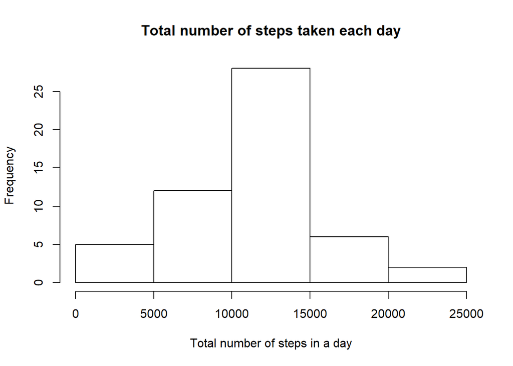

```r
hist(stepsByDay$total, main="Total number of steps taken each day", xlab="Total number of steps in a day")
```

3. Calculate and report the mean and median of the total number of steps taken per day

```r
df_mean <- summarise(stepsByDay, Mean = mean(total, na.rm=T))
df_median <- summarise(stepsByDay, Median = median(total, na.rm=T))
```

The mean total number of steps per day is 10766 and the median is 10765.

## What is the average daily activity pattern?

1. Make a time series plot (i.e. type=“l”) of the 5-minute interval (x-axis) and the average number of steps taken, averaged across all days (y-axis)

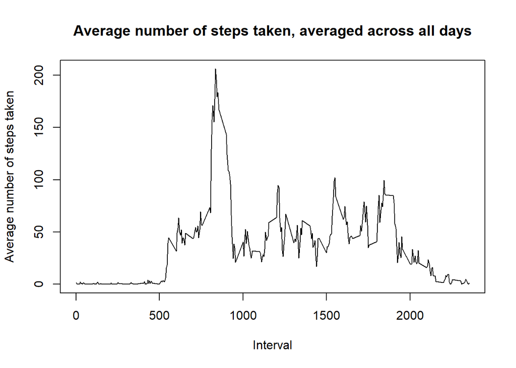

```r
stepsByInterval <- aggregate(df$steps, by=list(df$interval), FUN=mean, na.rm=T)
plot(x=stepsByInterval$Group.1, stepsByInterval$x, type="l", main="Average number of steps taken, averaged across all days", xlab="Interval", ylab="Average number of steps taken")
```

2. Which 5-minute interval, on average across all the days in the dataset, contains the maximum number of steps?

```r
maxInterval <- which.max(stepsByInterval$x)
stepsByInterval[maxInterval,]
```

```
##     Group.1        x
## 104     835 206.1698
```

The 5-minute interval with the maximum number of steps is 104th interval.

## Imputing missing values

Note that there are a number of days/intervals where there are missing values (coded as NA). The presence of missing days may introduce bias into some calculations or summaries of the data.

1. Calculate and report the total number of missing values in the dataset (i.e. the total number of rows with NAs)

```r
totalNA <- sum(is.na(df))
```

The total number of missing values is 2304.

2. Devise a strategy for filling in all of the missing values in the dataset. The strategy does not need to be sophisticated. For example, you could use the mean/median for that day, or the mean for that 5-minute interval, etc.

3. Create a new dataset that is equal to the original dataset but with the missing data filled in.

```r
df$steps[is.na(df$steps)]<-mean(df$steps,na.rm=TRUE)
```

Check that there are no missing values

```r
sum(is.na(df$steps))
```

```
## [1] 0
```

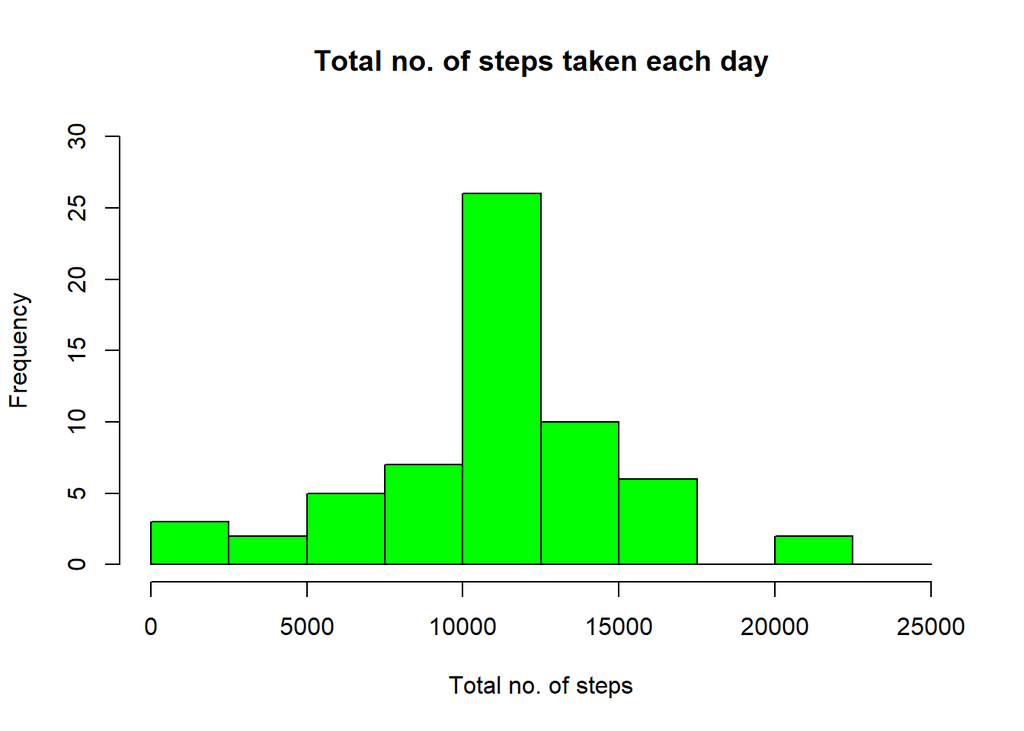

```r
sum_steps <- aggregate(df$steps, by = list(df$date), FUN=sum, na.rm=TRUE)
hist(sum_steps$x,
     breaks=seq(from=0, to=25000, by=2500),
     col="green",
     xlab="Total no. of steps",
     ylim=c(0,30),
     main="Total no. of steps taken each day")
```

## Are there differences in activity patterns between weekdays and weekends?

For this part the weekdays() function may be of some help here. Use the dataset with the filled-in missing values for this part.

1. Create a new factor variable in the dataset with two levels - “weekday” and “weekend” indicating whether a given date is a weekday or weekend day.
2. Make a panel plot containing a time series plot (i.e. type=“l”) of the 5-minute interval (x-axis) and the average number of steps taken, averaged across all weekday days or weekend days (y-axis). See the README file in the GitHub repository to see an example of what this plot should look like using simulated data.

```r
df$days=tolower(weekdays(df$date))
```

Categorize between weekdays and weekends

```r
df$day_type <- ifelse(df$days=="saturday"|df$days=="sunday","weekend","weekday")
```

Compute mean of steps on weekend or weekday in the intervals

```r
avg_steps <- aggregate(df$steps, by = list(df$interval, df$day_type), FUN=mean, na.rm=TRUE)
colnames(avg_steps) <- c("interval","day_type", "steps")
```

Create panel plot

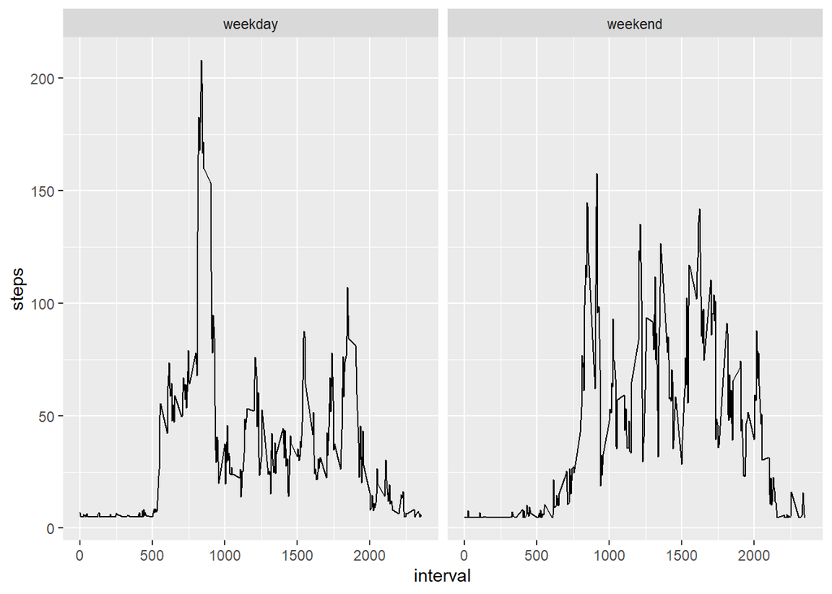

```r
ggplot(aes(x=interval, y=steps), data=avg_steps)+geom_line()+facet_wrap(~avg_steps$day_type)
```